# Practical Machine Learning

Dineshkumar Murugan

Sunday, May 24, 2015

## Background

Using devices such as Jawbone Up, Nike FuelBand, and Fitbit it is now possible to collect a large amount of data about personal activity relatively inexpensively. These type of devices are part of the quantified self movement - a group of enthusiasts who take measurements about themselves regularly to improve their health, to find patterns in their behavior, or because they are tech geeks. One thing that people regularly do is quantify how much of a particular activity they do, but they rarely quantify how well they do it. In this project, your goal will be to use data from accelerometers on the belt, forearm, arm, and dumbell of 6 participants. They were asked to perform barbell lifts correctly and incorrectly in 5 different ways. More information is available from the website here: http://groupware.les.inf.puc-rio.br/har (see the section on the Weight Lifting Exercise Dataset).

## Data

The training data for this project are available here: https://d396qusza40orc.cloudfront.net/predmachlearn/pml-training.csv The test data are available here: https://d396qusza40orc.cloudfront.net/predmachlearn/pml-testing.csv The data for this project come from this source: http://groupware.les.inf.puc-rio.br/har. If you use the document you create for this class for any purpose please cite them as they have been very generous in allowing their data to be used for this kind of assignment.

## What you should submit

The goal of your project is to predict the manner in which they did the exercise. This is the “classe” variable in the training set. You may use any of the other variables to predict with. You should create a report describing how you built your model, how you used cross validation, what you think the expected out of sample error is, and why you made the choices you did. You will also use your prediction model to predict 20 different test cases. Your submission should consist of a link to a Github repo with your R markdown and compiled HTML file describing your analysis. Please constrain the text of the writeup to < 2000 words and the number of figures to be less than 5. It will make it easier for the graders if you submit a repo with a gh-pages branch so the HTML page can be viewed online (and you always want to make it easy on graders :-). You should also apply your machine learning algorithm to the 20 test cases available in the test data above. Please submit your predictions in appropriate format to the programming assignment for automated grading. See the programming assignment for additional details.

## Reproducibility

Due to security concerns with the exchange of R code, your code will not be run during the evaluation by your classmates. Please be sure that if they download the repo, they will be able to view the compiled HTML version of your analysis.

# Prepare the datasets

```r
##Creating Dataframe from the downloaded csv files

train_data <- read.csv(file = "~/GitDinesh/Practical-Machine-Learning/pml-training.csv", na.strings=c("", "NA"))
test_data <- read.csv(file = "~/GitDinesh/Practical-Machine-Learning/pml-testing.csv", na.strings=c("", "NA"))

##Removing the columns with 'NA's

train_data<-train_data[,colSums(is.na(train_data)) == 0]
test_data <-test_data[,colSums(is.na(test_data)) == 0]


##Removing irrelevant columns -  user_name, raw_timestamp_part_1, raw_timestamp_part_,2 cvtd_timestamp, new_window, and  num_window (columns 1 to 7)
train_data   <-train_data[,-c(1:7)]
test_data <-test_data[,-c(1:7)]
```

# Explratory Data Analysis

```r
head(train_data)
```

```
##   roll_belt pitch_belt yaw_belt total_accel_belt gyros_belt_x gyros_belt_y
## 1      1.41       8.07    -94.4                3         0.00         0.00
## 2      1.41       8.07    -94.4                3         0.02         0.00
## 3      1.42       8.07    -94.4                3         0.00         0.00
## 4      1.48       8.05    -94.4                3         0.02         0.00
## 5      1.48       8.07    -94.4                3         0.02         0.02
## 6      1.45       8.06    -94.4                3         0.02         0.00
##   gyros_belt_z accel_belt_x accel_belt_y accel_belt_z magnet_belt_x
## 1        -0.02          -21            4           22            -3
## 2        -0.02          -22            4           22            -7
## 3        -0.02          -20            5           23            -2
## 4        -0.03          -22            3           21            -6
## 5        -0.02          -21            2           24            -6
## 6        -0.02          -21            4           21             0
##   magnet_belt_y magnet_belt_z roll_arm pitch_arm yaw_arm total_accel_arm
```

[output cut: 69 more lines]

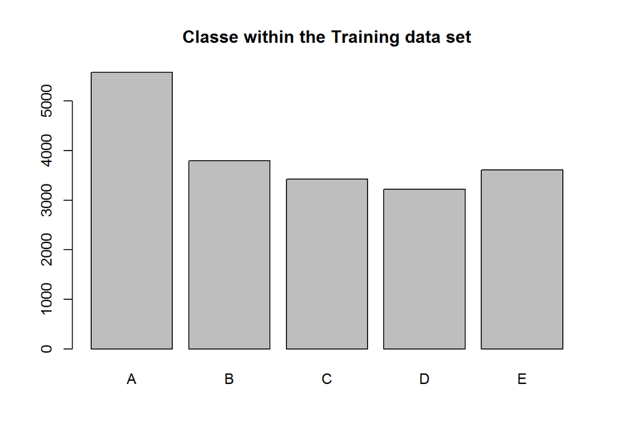

```r
##A Look into the data
plot(x = train_data$classe,main = "Classe within the Training data set")
```

# Training the Model

```r
library(randomForest)
library(caret)
library(parallel)
library(doParallel)
##Partion the Dataset
inTrain <- createDataPartition( y= train_data$classe, p = 0.75 , list = FALSE)
trainingSet <- train_data[inTrain,]
testingSet <- train_data[-inTrain,]
```

Initializing Parallel Processing

```r
cl <- makeCluster(detectCores() - 1)
registerDoParallel(cl)
```

Training the Model

```r
trcntrl <- trainControl(classProbs=TRUE,
                     savePredictions=TRUE,
                     allowParallel=TRUE)


trainingModel <- train(classe ~ ., data=trainingSet, method="rf",trControl = trcntrl)
```

Initial Test with confustion matrix

```r
predictedfromtrains <- predict(trainingModel, trainingSet)
confusionMatrix(predictedfromtrains, trainingSet$classe)
```

```
## Confusion Matrix and Statistics
##
##           Reference
## Prediction    A    B    C    D    E
##          A 4185    0    0    0    0
##          B    0 2848    0    0    0
##          C    0    0 2567    0    0
##          D    0    0    0 2412    0
##          E    0    0    0    0 2706
##
## Overall Statistics
##
##                Accuracy : 1
##                  95% CI : (0.9997, 1)
##     No Information Rate : 0.2843
##     P-Value [Acc > NIR] : < 2.2e-16
##
##                   Kappa : 1
##  Mcnemar's Test P-Value : NA
##
## Statistics by Class:
##
##                      Class: A Class: B Class: C Class: D Class: E
## Sensitivity            1.0000   1.0000   1.0000   1.0000   1.0000
## Specificity            1.0000   1.0000   1.0000   1.0000   1.0000
## Pos Pred Value         1.0000   1.0000   1.0000   1.0000   1.0000
## Neg Pred Value         1.0000   1.0000   1.0000   1.0000   1.0000
## Prevalence             0.2843   0.1935   0.1744   0.1639   0.1839
## Detection Rate         0.2843   0.1935   0.1744   0.1639   0.1839
## Detection Prevalence   0.2843   0.1935   0.1744   0.1639   0.1839
## Balanced Accuracy      1.0000   1.0000   1.0000   1.0000   1.0000
```

closing the parallel processing mode

```r
stopCluster(cl)
```

Variance Test

```r
varImp(trainingModel)
```

```
## rf variable importance
##
##   only 20 most important variables shown (out of 52)
##
##                      Overall
## roll_belt             100.00
## pitch_forearm          59.24
## yaw_belt               55.99
## pitch_belt             45.34
## magnet_dumbbell_z      43.79
## magnet_dumbbell_y      41.46
## roll_forearm           40.50
## accel_dumbbell_y       22.02
## accel_forearm_x        17.46
## magnet_dumbbell_x      17.42
## roll_dumbbell          17.32
## magnet_belt_z          16.14
## magnet_forearm_z       14.12
## accel_belt_z           13.87
## accel_dumbbell_z       13.80
## total_accel_dumbbell   13.28
## magnet_belt_y          12.64
## gyros_belt_z           11.35
## magnet_belt_x          10.81
## yaw_arm                10.29
```

A look into final model parameters

```r
trainingModel$finalModel
```

```
##
## Call:
##  randomForest(x = x, y = y, mtry = param$mtry)
##                Type of random forest: classification
##                      Number of trees: 500
## No. of variables tried at each split: 27
##
##         OOB estimate of  error rate: 0.55%
## Confusion matrix:
##      A    B    C    D    E class.error
## A 4178    5    1    0    1 0.001672640
## B   18 2824    6    0    0 0.008426966
## C    0    8 2549   10    0 0.007012076
## D    0    0   17 2392    3 0.008291874
## E    0    1    3    8 2694 0.004434590
```

Saving the training Model for future purpose

```r
save(trainingModel, file="trainingModel.RData")
```

# Validating the Model

```r
predictedfromtestV <- predict(trainingModel, testingSet)


confusionMatrix(predictedfromtestV, testingSet$classe)
```

```
## Confusion Matrix and Statistics
##
##           Reference
## Prediction    A    B    C    D    E
##          A 1395   13    0    0    0
##          B    0  935    5    0    0
##          C    0    1  848   12    4
##          D    0    0    2  792    0
##          E    0    0    0    0  897
##
## Overall Statistics
##
##                Accuracy : 0.9925
##                  95% CI : (0.9896, 0.9947)
##     No Information Rate : 0.2845
##     P-Value [Acc > NIR] : < 2.2e-16
##
##                   Kappa : 0.9905
##  Mcnemar's Test P-Value : NA
##
## Statistics by Class:
##
##                      Class: A Class: B Class: C Class: D Class: E
## Sensitivity            1.0000   0.9852   0.9918   0.9851   0.9956
## Specificity            0.9963   0.9987   0.9958   0.9995   1.0000
## Pos Pred Value         0.9908   0.9947   0.9803   0.9975   1.0000
## Neg Pred Value         1.0000   0.9965   0.9983   0.9971   0.9990
## Prevalence             0.2845   0.1935   0.1743   0.1639   0.1837
## Detection Rate         0.2845   0.1907   0.1729   0.1615   0.1829
## Detection Prevalence   0.2871   0.1917   0.1764   0.1619   0.1829
## Balanced Accuracy      0.9981   0.9920   0.9938   0.9923   0.9978
```

Accuracy is 0.992 - which is pretty good.

# Prediciting the Test Set

```r
load(file="trainingModel.RData", verbose=TRUE)
```

```
## Loading objects:
##   trainingModel
```

```r
predictedV <- predict(trainingModel, test_data)
test_data <- cbind(predictedV , test_data)
test_data$predictedV
```

```
##  [1] B A B A A E D B A A B C B A E E A B B B
## Levels: A B C D E
```

The real answer is “B”,“A”,“B”,“A”,“A”,“E”,“D”,“B”,“A”,“A”,“B”,“C”,“B”,“A”,“E”,“E”,“A”,“B”,“B”,“B”

Overall from the output and accuracy level this is a good prediction.